# StockPrediction

Introduction

In this project, we aim to build a machine learning model to accurately predict the next day's price of the S&P 500 index. Our data comes from the yfinance library and contains daily stock information dating back to 1927, including opening, high, low, and close prices. Additionally, there is a volume column showing the daily traded volume. Other columns in the dataset will be removed, as they are not relevant to our analysis. We will add new features of interest during the feature engineering process.

Results

First, we extracted data from the yfinance library and added several key features. We created a new column called Tomorrow, which represents the closing price of the stock on the following day. We also added a binary column called Target, where a value of 0 indicates that the stock price decreased the next day, and a value of 1 indicates that the price increased. These columns were essential for training our model by providing a clear metric to predict.

In addition to feature engineering, I increased the prediction confidence threshold. Instead of predicting an increase when the model had over 50% confidence, I raised the threshold to 60%, which led to an even higher precision score. This adjustment ensured the model only predicted price increases when it was relatively certain, further improving its accuracy.

These refinements enabled us to create a reliable stock price prediction model for the S&P 500. Looking ahead, future improvements could involve adding more predictors, such as data from other stocks or international markets with different operating hours. Incorporating such factors might further enhance the model's accuracy.

```python
import yfinance as yf
```

```python
sp500 = yf.Ticker("^GSPC")
```

```python
sp500 = sp500.history(period="max")
```

```python
sp500
```

| Date | Open | High | Low | Close | Volume | Dividends | Stock Splits |
| --- | --- | --- | --- | --- | --- | --- | --- |
| 1927-12-30 00:00:00-05:00 | 17.660000 | 17.660000 | 17.660000 | 17.660000 | 0 | 0.0 | 0.0 |
| 1928-01-03 00:00:00-05:00 | 17.760000 | 17.760000 | 17.760000 | 17.760000 | 0 | 0.0 | 0.0 |
| 1928-01-04 00:00:00-05:00 | 17.719999 | 17.719999 | 17.719999 | 17.719999 | 0 | 0.0 | 0.0 |
| 1928-01-05 00:00:00-05:00 | 17.549999 | 17.549999 | 17.549999 | 17.549999 | 0 | 0.0 | 0.0 |
| 1928-01-06 00:00:00-05:00 | 17.660000 | 17.660000 | 17.660000 | 17.660000 | 0 | 0.0 | 0.0 |
| ... | ... | ... | ... | ... | ... | ... | ... |
| 2024-09-09 00:00:00-04:00 | 5442.069824 | 5484.200195 | 5434.490234 | 5471.049805 | 3825940000 | 0.0 | 0.0 |
| 2024-09-10 00:00:00-04:00 | 5490.509766 | 5497.910156 | 5441.720215 | 5495.520020 | 3848180000 | 0.0 | 0.0 |
| 2024-09-11 00:00:00-04:00 | 5496.419922 | 5560.410156 | 5406.959961 | 5554.129883 | 3839450000 | 0.0 | 0.0 |
| 2024-09-12 00:00:00-04:00 | 5557.479980 | 5600.709961 | 5535.500000 | 5595.759766 | 3655070000 | 0.0 | 0.0 |
| 2024-09-13 00:00:00-04:00 | 5603.339844 | 5636.270020 | 5601.649902 | 5626.020020 | 3500790000 | 0.0 | 0.0 |

24292 rows × 7 columns

```python
sp500.index
```

```
DatetimeIndex(['1927-12-30 00:00:00-05:00', '1928-01-03 00:00:00-05:00',
               '1928-01-04 00:00:00-05:00', '1928-01-05 00:00:00-05:00',
               '1928-01-06 00:00:00-05:00', '1928-01-09 00:00:00-05:00',
               '1928-01-10 00:00:00-05:00', '1928-01-11 00:00:00-05:00',
               '1928-01-12 00:00:00-05:00', '1928-01-13 00:00:00-05:00',
               ...
               '2024-08-30 00:00:00-04:00', '2024-09-03 00:00:00-04:00',
               '2024-09-04 00:00:00-04:00', '2024-09-05 00:00:00-04:00',
               '2024-09-06 00:00:00-04:00', '2024-09-09 00:00:00-04:00',
               '2024-09-10 00:00:00-04:00', '2024-09-11 00:00:00-04:00',
               '2024-09-12 00:00:00-04:00', '2024-09-13 00:00:00-04:00'],
              dtype='datetime64[ns, America/New_York]', name='Date', length=24292, freq=None)
```

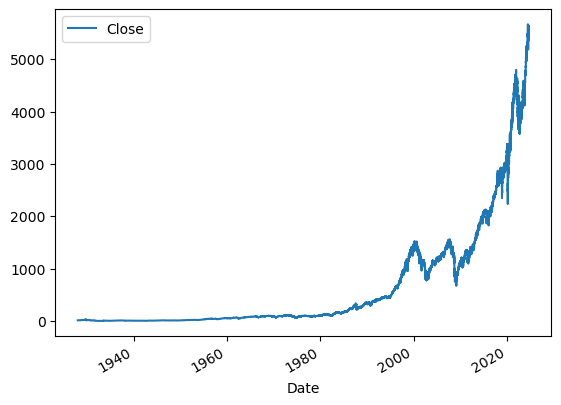

```python
sp500.plot.line(y="Close", use_index=True)
```

```python
del sp500["Dividends"]
del sp500["Stock Splits"]
```

```python
sp500["Tomorrow"] = sp500["Close"].shift(-1)
```

```python
sp500["Target"] = (sp500["Tomorrow"] > sp500["Close"]).astype(int)
```

```python
sp500 = sp500.loc["1990-01-01":].copy()
```

```python
sp500
```

| Date | Open | High | Low | Close | Volume | Tomorrow | Target |
| --- | --- | --- | --- | --- | --- | --- | --- |
| 1990-01-02 00:00:00-05:00 | 353.399994 | 359.690002 | 351.980011 | 359.690002 | 162070000 | 358.760010 | 0 |
| 1990-01-03 00:00:00-05:00 | 359.690002 | 360.589996 | 357.890015 | 358.760010 | 192330000 | 355.670013 | 0 |
| 1990-01-04 00:00:00-05:00 | 358.760010 | 358.760010 | 352.890015 | 355.670013 | 177000000 | 352.200012 | 0 |
| 1990-01-05 00:00:00-05:00 | 355.670013 | 355.670013 | 351.350006 | 352.200012 | 158530000 | 353.790009 | 1 |
| 1990-01-08 00:00:00-05:00 | 352.200012 | 354.239990 | 350.540009 | 353.790009 | 140110000 | 349.619995 | 0 |
| ... | ... | ... | ... | ... | ... | ... | ... |
| 2024-09-09 00:00:00-04:00 | 5442.069824 | 5484.200195 | 5434.490234 | 5471.049805 | 3825940000 | 5495.520020 | 1 |
| 2024-09-10 00:00:00-04:00 | 5490.509766 | 5497.910156 | 5441.720215 | 5495.520020 | 3848180000 | 5554.129883 | 1 |
| 2024-09-11 00:00:00-04:00 | 5496.419922 | 5560.410156 | 5406.959961 | 5554.129883 | 3839450000 | 5595.759766 | 1 |
| 2024-09-12 00:00:00-04:00 | 5557.479980 | 5600.709961 | 5535.500000 | 5595.759766 | 3655070000 | 5626.020020 | 1 |
| 2024-09-13 00:00:00-04:00 | 5603.339844 | 5636.270020 | 5601.649902 | 5626.020020 | 3500790000 | NaN | 0 |

8742 rows × 7 columns

```python
from sklearn.ensemble import RandomForestClassifier

model = RandomForestClassifier(n_estimators = 100, min_samples_split = 100, random_state=1)
# since this is time series data we can't use cross validation to check our model because it will use future data to predict previous prices. This can lead to misleading high accuracy in tresting and low accuracy in the real world
train = sp500.iloc[:-100]
test = sp500.iloc[-100:]

predictors = ["Close", "Volume", "Open", "High", "Low"]
model.fit(train[predictors], train["Target"])
```

```
RandomForestClassifier(min_samples_split=100, random_state=1)
```

```python
from sklearn.metrics import precision_score
# when we said it went up did it acutally go up
preds = model.predict(test[predictors])
```

```python
import pandas as pd

preds = pd.Series(preds, index = test.index)
```

```python
precision_score(test["Target"], preds)
```

```
0.8
```

```python
combined = pd.concat([test["Target"], preds], axis =1 )
```

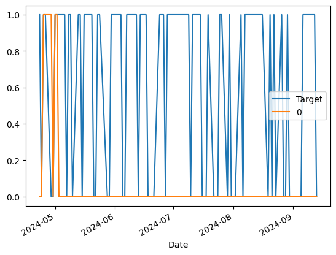

```python
combined.plot()
```

```python
def predict(train, test, predictors, model):
    model.fit(train[predictors], train["Target"])
    preds = model.predict(test[predictors])
    preds = pd.Series(preds,index=test.index, name = "Predictions")
    combined = pd.concat([test["Target"], preds], axis = 1)
    return combined
```

```python
def backtest(data, model, predictors, start = 2500, step = 250):
    all_predictions = []

    for i in range(start, data.shape[0], step):
        train = data.iloc[0:i].copy()
        test = data.iloc[i: (i+step)].copy()
        predictions = predict(train, test, predictors, model)
        all_predictions.append(predictions)
    return pd.concat(all_predictions)
```

```python
predictions = backtest(sp500, model, predictors)
```

```python
predictions["Predictions"].value_counts()
```

```
Predictions
0    3640
1    2602
Name: count, dtype: int64
```

```python
precision_score(predictions["Target"], predictions["Predictions"])
```

```
0.5292083013066872
```

```python
predictions["Target"].value_counts() / predictions.shape[0]
```

```
Target
1    0.535566
0    0.464434
Name: count, dtype: float64
```

```python
horizons = [2, 5, 60, 250, 1000]
new_predictors = []

for horizon in horizons:
    rolling_average = sp500.rolling(horizon).mean()

    ratio_column = f"Close_Ratio_{horizon}"
    sp500[ratio_column] = sp500["Close"] / rolling_average["Close"]

    trend_column = f"Trend_{horizon}"
    sp500[trend_column] = sp500.shift(1).rolling(horizon).sum()["Target"]

    new_predictors += [ratio_column, trend_column]
```

```python
sp500 = sp500.dropna()
```

```python
sp500
```

| Date | Open | High | Low | Close | Volume | Tomorrow | Target | Close_Ratio_2 | Trend_2 | Close_Ratio_5 | Trend_5 | Close_Ratio_60 | Trend_60 | Close_Ratio_250 | Trend_250 | Close_Ratio_1000 | Trend_1000 |
| --- | --- | --- | --- | --- | --- | --- | --- | --- | --- | --- | --- | --- | --- | --- | --- | --- | --- |
| 1993-12-14 00:00:00-05:00 | 465.730011 | 466.119995 | 462.459991 | 463.059998 | 275050000 | 461.839996 | 0 | 0.997157 | 1.0 | 0.996617 | 1.0 | 1.000283 | 32.0 | 1.028047 | 127.0 | 1.176082 | 512.0 |
| 1993-12-15 00:00:00-05:00 | 463.059998 | 463.690002 | 461.839996 | 461.839996 | 331770000 | 463.339996 | 1 | 0.998681 | 0.0 | 0.995899 | 1.0 | 0.997329 | 32.0 | 1.025151 | 126.0 | 1.172676 | 512.0 |
| 1993-12-16 00:00:00-05:00 | 461.859985 | 463.980011 | 461.859985 | 463.339996 | 284620000 | 466.380005 | 1 | 1.001621 | 1.0 | 0.999495 | 2.0 | 1.000311 | 32.0 | 1.028274 | 127.0 | 1.176163 | 513.0 |
| 1993-12-17 00:00:00-05:00 | 463.339996 | 466.380005 | 463.339996 | 466.380005 | 363750000 | 465.850006 | 0 | 1.003270 | 2.0 | 1.004991 | 3.0 | 1.006561 | 32.0 | 1.034781 | 128.0 | 1.183537 | 514.0 |
| 1993-12-20 00:00:00-05:00 | 466.380005 | 466.899994 | 465.529999 | 465.850006 | 255900000 | 465.299988 | 0 | 0.999431 | 1.0 | 1.003784 | 2.0 | 1.005120 | 32.0 | 1.033359 | 128.0 | 1.181856 | 513.0 |
| ... | ... | ... | ... | ... | ... | ... | ... | ... | ... | ... | ... | ... | ... | ... | ... | ... | ... |
| 2024-09-06 00:00:00-04:00 | 5507.330078 | 5522.470215 | 5402.620117 | 5408.419922 | 3822800000 | 5471.049805 | 1 | 0.991295 | 0.0 | 0.979459 | 1.0 | 0.983825 | 34.0 | 1.084735 | 143.0 | 1.246199 | 524.0 |
| 2024-09-09 00:00:00-04:00 | 5442.069824 | 5484.200195 | 5434.490234 | 5471.049805 | 3825940000 | 5495.520020 | 1 | 1.005757 | 1.0 | 0.997207 | 1.0 | 0.995066 | 34.0 | 1.096431 | 143.0 | 1.260025 | 525.0 |
| 2024-09-10 00:00:00-04:00 | 5490.509766 | 5497.910156 | 5441.720215 | 5495.520020 | 3848180000 | 5554.129883 | 1 | 1.002231 | 2.0 | 1.002888 | 2.0 | 0.999330 | 34.0 | 1.100423 | 144.0 | 1.265038 | 526.0 |
| 2024-09-11 00:00:00-04:00 | 5496.419922 | 5560.410156 | 5406.959961 | 5554.129883 | 3839450000 | 5595.759766 | 1 | 1.005304 | 2.0 | 1.012325 | 3.0 | 1.009613 | 35.0 | 1.111192 | 144.0 | 1.277872 | 527.0 |
| 2024-09-12 00:00:00-04:00 | 5557.479980 | 5600.709961 | 5535.500000 | 5595.759766 | 3655070000 | 5626.020020 | 1 | 1.003734 | 2.0 | 1.016491 | 4.0 | 1.016803 | 35.0 | 1.118544 | 144.0 | 1.286765 | 528.0 |

7741 rows × 17 columns

```python
model = RandomForestClassifier(n_estimators = 200, min_samples_split= 50, random_state = 1)
```

```python
def predict(train, test, predictors, model):
    model.fit(train[predictors], train["Target"])
    preds = model.predict_proba(test[predictors])[:,1]
    preds[preds >= 0.6] = 1
    preds[preds < 0.6] = 0
    preds = pd.Series(preds,index=test.index, name = "Predictions")
    combined = pd.concat([test["Target"], preds], axis = 1)
    return combined
```

```python
predictions = backtest(sp500, model, new_predictors)
```

```python
predictions["Predictions"].value_counts()
```

```
Predictions
0.0    4397
1.0     844
Name: count, dtype: int64
```

```python
precision_score(predictions["Target"], predictions["Predictions"])
```

```
0.5746445497630331
```